# From Startup Chaos to Smart Deal Flow

Using AI to Help VCs Pick Better Companies

Eesha Jagdhane

June 5, 2026

From Startup Chaos to Smart Deal Flow

### Using AI to Help VCs Pick Better Companies

**Eesha Jagdhane** · MGTA 495 · Marketing Analytics

Marketing analytics applied to venture capital — turning messy deal flow into smarter, prioritized investment decisions.

All quantitative results in this deck come from a **simulated multi-source VC dataset**. The pipeline design mirrors a real end-to-end build.

## The Problem & The Data

VCs review thousands of startups across fragmented sources — partner time is limited. We built on a fully synthetic, privacy-safe dataset with the same structure as real VC exports.

60,000

Raw startup records

~44K

Unique after dedupe

3

Data sources

- Signals live across **CRM**, **Harmonic**, and **PitchBook**
- Partner time is the scarcest resource — most deals never get a real look
- **~40% intentional overlap** across sources to test entity resolution
- CRM labels: **~5,400 positive** · **~14,600 negative**
- No real company names or contact information in this deck

| Source | Records | Key fields |
| --- | --- | --- |
| Simulated CRM | 20,000 | Status, thesis area, geo, funding, investors |
| Simulated Harmonic | 20,000 | Descriptions, headcount, 90d growth, tags |
| Simulated PitchBook | 20,000 | Industry, verticals, financing, HQ |

The issue is not a lack of data — it is **too much scattered data** and **not enough partner attention**.

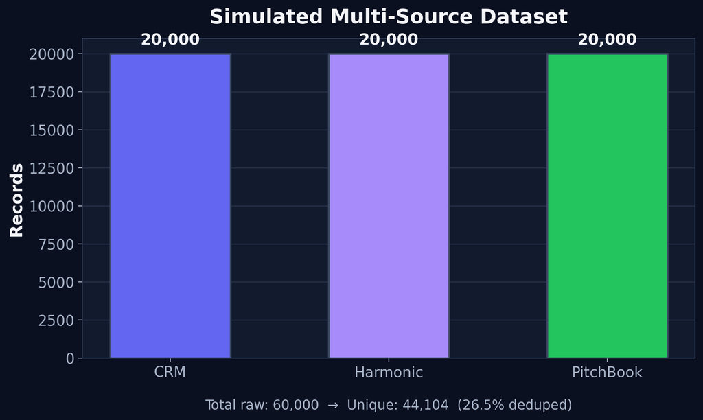

Simulated data volume across three sources

Simulated CRM, Harmonic, and PitchBook exports · 20,000 records each

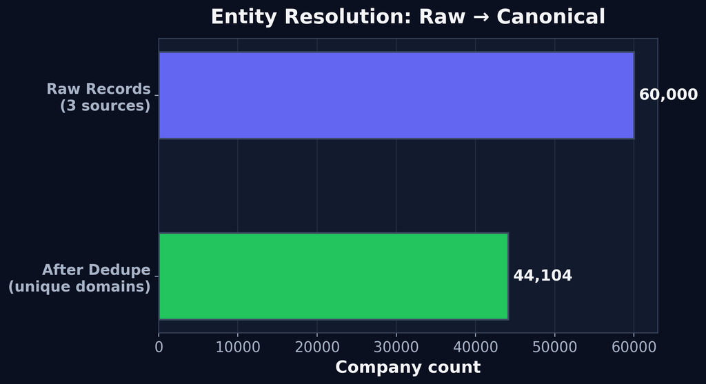

Entity resolution: raw records to canonical companies

60,000 raw → 44,104 unique companies · **26.5%** dedupe rate

## Before AI

The traditional process is manual, inconsistent, and hard to scale.

CRM Data

→

Spreadsheets

→

Manual Research

→

PitchBook / Harmonic

→

Gut Feeling

→

Partner Review

Slow

Inconsistent

Hard to Scale

Data Silos

Manual screening is uneven and time-bound — high-potential startups slip through when analysts cannot research every company the same way.

## AI-Assisted Deal Flow

AI gives deal flow a brain — unified data, faster insight, and prioritized review.

AI Summaries

Investment Signals

Relevance Scoring

Prioritized Deal Flow

**Relevance scoring is not a black-box model** — it is a transparent weighted layer that ranks companies using partner-selected investment criteria.

AI doesn’t replace judgment — it **front-loads intelligence** so investors spend time where it matters.

## Key Drivers

Segment the universe, then rank companies with a transparent weighted scoring model partners control.

**Score (0–100)** = Σ (Partner Weight × Driver Score)

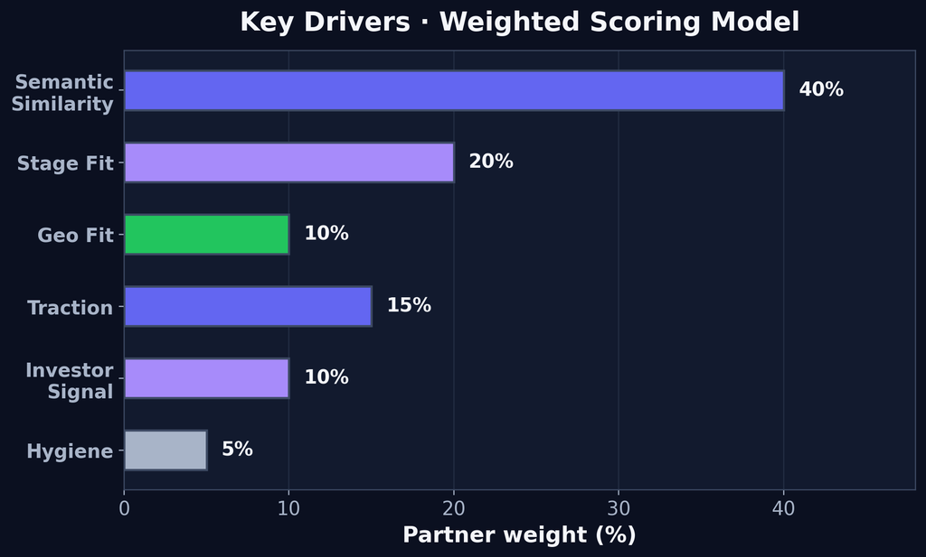

Partner-adjustable driver weights

Six key drivers · weights sum to 100%

| Driver | Weight | How calculated |
| --- | --- | --- |
| Semantic similarity | 40% | Thesis vs. company text · cosine similarity |
| Stage fit | 20% | Rule-based match to Seed / Early |
| Geo fit | 10% | Rule-based match to target geographies |
| Traction | 15% | Headcount growth + funding recency |
| Investor signal | 10% | Normalized investor count |
| Hygiene | 5% | Data completeness score |

**Not** a Random Forest or MSE model — this is **attribution-style explainability**: every score decomposes into points per driver.

## Score Breakdown

Every ranked company gets a transparent point contribution per driver — like marketing attribution.

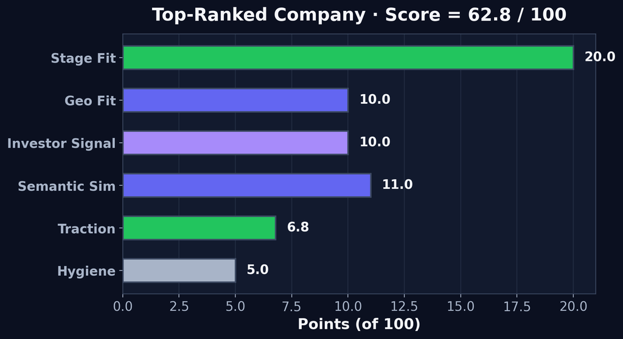

Point contributions for the top-ranked company

Top-ranked company · Score = **62.8 / 100** (simulated)

Partners can reweight drivers by thesis — e.g., raise stage weight for a Series A focus, or semantic weight for a narrow AI-infra mandate.

62.8

Max score

26.8

Mean score

6

Drivers

Top contributors for the #1 company:

1. **Stage fit** — 20.0 pts
2. **Geo fit** — 10.0 pts
3. **Investor signal** — 10.0 pts
4. **Semantic similarity** — ~11.0 pts
5. **Traction** — ~6.8 pts
6. **Hygiene** — 5.0 pts

## Results

Did the ranking match historical CRM disposition labels?

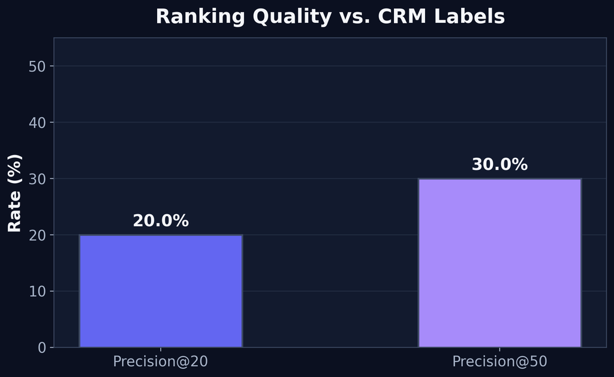

Precision at top-K against CRM labels

Backtested against simulated CRM positive / negative labels

20%

Precision@20

30%

Precision@50

5.4K

CRM positives

50

AI summaries

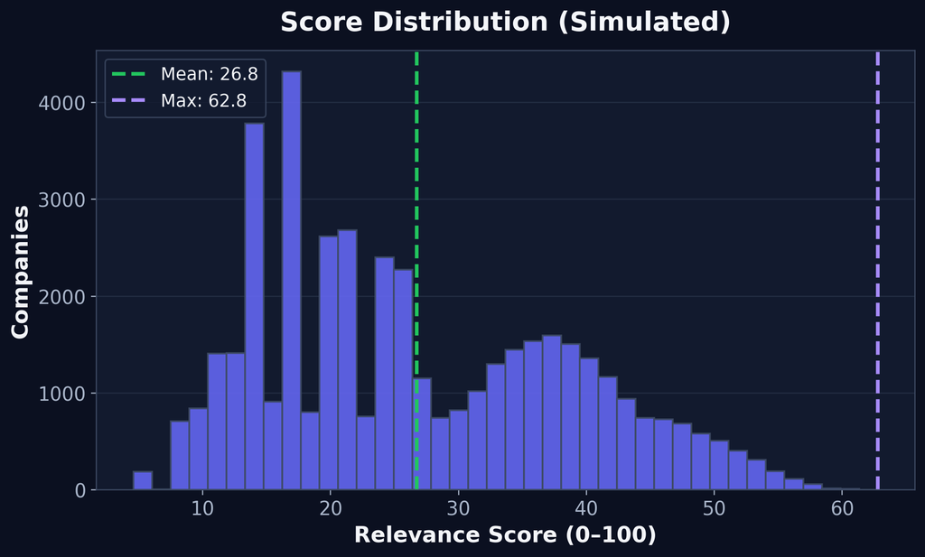

Score distribution across all ranked companies

The model is **selective** — mean score ~26.8, max ~62.8 — not inflating every company to the top of the list.

## Impact & The AI Arms Race

The goal is not to replace investors — it is to help them focus.

**Less Manual Screening** Automate the first pass across thousands of companies

**Faster Review** AI summaries cut research time from hours to minutes

**Consistent Scoring** Every deal evaluated with the same framework

**Better Data Use** CRM, Harmonic, and PitchBook signals unified

**Easier Prioritization** Ranked deal flow replaces gut-only triage

**Hidden Gems Found** Strong startups surface before competitors notice

**The AI arms race:** If VCs use AI to review startups, founders may use AI to optimize pitches. To avoid AI evaluating AI-generated language, rely on harder-to-fake signals: **funding history, headcount growth, investor quality, traction, and human judgment**.

> AI can polish a pitch, but it cannot easily fake traction.

This project applies marketing analytics thinking to venture capital: using **segmentation, weighted scoring, and attribution** to turn messy deal flow into smarter investment decisions.